# Project Step 2: Data Exploration

Zeke Krug

3/10/2023

## Project Overview

For my final project I plan to make a web app that produces the Valorant agent composition with the highest probability of winning given a map (only Ascent, Split, Haven, Pearl, Lotus, Fracture, and Icebox are player in the Competitive playlist) and player rank (Iron I through Diamond III).

With this project, I hope to describe agent usage patterns and also team composition patterns in Valorant. I am interested in seeing the differences in agent useage between the ranks.

## Description of Data

The data is a collection of statistics for each Valorant agent on certain maps, acquired from the website blitz.gg, which tracks game statistics. blitz.gg collects player data from the players that have the desktop app installed on their computer, and then combine all the data based on certain filters like Agent, Map, etc.

| Rank | Agent | Agent Class | KD | Kills | Deaths | Assists | Win % | Pick % | Avg. Score | First Blood % | Matches |
| --- | --- | --- | --- | --- | --- | --- | --- | --- | --- | --- | --- |
| int | chr | chr | num | num | num | num | num | num | int | num | int |

**Rank:** Ranking of agent based on Win %  
**Agent:** The name of the agent  
**Agent Class:** Agents are split into four categories: Duelist, Initiator, Controller, and Sentinel, with each providing different benefits  
**KD*:** Ratio describing the number of kills/number of deaths  
**Kills*:** The number of kills an agent gets in a match  
**Deaths*:** The number of times an agent dies in a match  
**Assists*:** The number of times an agent deals damage to an enemy, but another teammate secures the kill in a match  
**Win %:** The percentage of matches an agent wins  
**Pick %:** The percentage to matches an agent is picked to play  
**Avg. Score:** An in-game score given to players based on their performance throughout a match  
**First Blood %:** The percentage of times the first kill in the round is achieved by an agent  
**Matches:** The total number of matches that an agent has played  
* average across all matches

All data files can be found [here](https://github.com/krug0102/DataScienceFinalProject).

### Information about the Total Matches Played by each Agent on each Map

```
##     Agent               Ascent          Fracture          Haven
##  Length:21          Min.   : 26377   Min.   : 34972   Min.   : 26952
##  Class :character   1st Qu.: 70518   1st Qu.:103894   1st Qu.: 83558
##  Mode  :character   Median :119846   Median :132152   Median :131761
##                     Mean   :163509   Mean   :161554   Mean   :163851
##                     3rd Qu.:224530   3rd Qu.:218150   3rd Qu.:193770
##                     Max.   :380390   Max.   :376049   Max.   :391837
##      Icebox           Lotus            Pearl            Split
##  Min.   : 16579   Min.   : 58578   Min.   : 55763   Min.   : 30513
##  1st Qu.: 66891   1st Qu.: 92153   1st Qu.:100870   1st Qu.: 81252
##  Median : 93461   Median :134342   Median :136616   Median :119904
##  Mean   :141225   Mean   :161427   Mean   :161628   Mean   :163708
##  3rd Qu.:190823   3rd Qu.:232679   3rd Qu.:197405   3rd Qu.:223952
##  Max.   :377124   Max.   :381465   Max.   :387084   Max.   :440988
```

```
##         Agent Ascent Fracture  Haven Icebox  Lotus  Pearl  Split
##  1:     Astra  56135    34972  52710  16579  58578  88914  70161
##  2:    Breach  53248   218150  83558  34873 138661  55763  81252
##  3: Brimstone 193031   282846 186730  84624 150835 141911 167421
##  4:   Chamber  70518    84790  87137  77530 110126 101955  65544
##  5:    Cypher  98657   126606 122264  50518 108571 136616 157707
##  6:      Fade 119846   132152 125063  93461 134342 202945 119904
##  7:     Gekko 177423   175016 179690 151920 182729 181151 178578
##  8:    Harbor  26377    38064  26952  40941  77657  87698  30513
##  9:      Jett 327094   277251 324307 289913 270485 299988 266708
## 10:     KAY/O 119654   103894  97774 101884 110195 115142 109352
## 11:   Killjoy 342608   248291 228190 190823 232679 197405 223952
## 12:      Neon  62181   113608  70270  66891  87087  84429  67301
## 13:      Omen 290942   146247 324195 153560 254021 148115 274023
## 14:   Phoenix 122023   104496 132243  81546 120397 132708 108167
## 15:      Raze 206257   214756 193770 178684 245801 177688 291847
## 16:     Reyna 380390   376049 391837 339621 381465 387084 369424
## 17:      Sage 322651   324384 368009 377124 318556 352197 440988
## 18:      Skye 104883   111833 131761  82728 157017 128629 151987
## 19:      Sova 224530    74927 182310 213303  92153 100870  92478
## 20:     Viper  75501   140146  65248 277929  90219 200199 107029
## 21:      Yoru  59748    64149  66850  61275  68394  72774  63532
##         Agent Ascent Fracture  Haven Icebox  Lotus  Pearl  Split
```

[output not shown]

### Summary of the Average Win %s on each Map

```
##  Agent...Average.Win.Rate     Ascent         Fracture         Haven
##  Length:21                Min.   :44.76   Min.   :45.99   Min.   :45.29
##  Class :character         1st Qu.:48.29   1st Qu.:48.16   1st Qu.:48.13
##  Mode  :character         Median :48.92   Median :48.89   Median :48.86
##                           Mean   :48.75   Mean   :48.86   Mean   :48.80
##                           3rd Qu.:49.98   3rd Qu.:49.78   3rd Qu.:49.82
##                           Max.   :51.41   Max.   :51.07   Max.   :50.96
##      Icebox          Lotus           Pearl           Split
##  Min.   :46.16   Min.   :46.57   Min.   :46.30   Min.   :45.16
##  1st Qu.:47.78   1st Qu.:48.64   1st Qu.:48.27   1st Qu.:48.41
##  Median :48.96   Median :49.19   Median :49.01   Median :49.03
##  Mean   :48.78   Mean   :49.22   Mean   :49.14   Mean   :48.76
##  3rd Qu.:50.09   3rd Qu.:50.17   3rd Qu.:50.44   3rd Qu.:49.94
##  Max.   :50.80   Max.   :51.33   Max.   :51.85   Max.   :50.71
```

```
##     Agent...Average.Win.Rate   Ascent Fracture    Haven   Icebox    Lotus
##  1:                    Astra 49.18333 47.28333 48.12778 49.16111 50.02222
##  2:                   Breach 47.79444 49.25556 48.42778 47.61667 49.55000
##  3:                Brimstone 51.41111 51.07222 50.96111 48.96111 50.96667
##  4:                  Chamber 48.28889 48.57222 48.23333 48.35556 49.16111
##  5:                   Cypher 48.92222 48.89444 48.76111 46.93333 49.16111
##  6:                     Fade 48.45556 48.86111 48.86111 48.66667 48.95556
##  7:                    Gekko 49.13333 50.31667 50.79444 50.68333 51.32778
##  8:                   Harbor 44.76111 46.63333 45.29444 47.48889 47.42222
##  9:                     Jett 49.02222 49.50000 49.39444 50.09444 49.19444
## 10:                    KAY/O 45.76111 45.98889 45.73333 46.81667 46.56667
## 11:                  Killjoy 50.59444 50.92778 50.75556 50.80000 50.68333
## 12:                     Neon 47.27778 48.66111 47.32778 47.77778 48.06667
## 13:                     Omen 48.76111 46.66111 48.75556 48.01667 48.67222
## 14:                  Phoenix 50.41111 49.77222 50.35000 49.59444 49.97778
```

[output cut: 31 more lines]

```
**Observations**
Win % might not be a very useful statistic, as when the same agent is on both teams one usually wins and one usually loses (ties are possible). Win % is also dependent on many factors.  However, Win % shows which agents are more successful than not.

Brimstone, Gekko, Killjoy, and Sage consistently hover around the 50% Win % mark and one of them will usually have the highest on each map.  This suggests that these four agents are important to a teams success.
```

### Barplots Showing how many Times an Agent Would have the Highest Win % on a Map

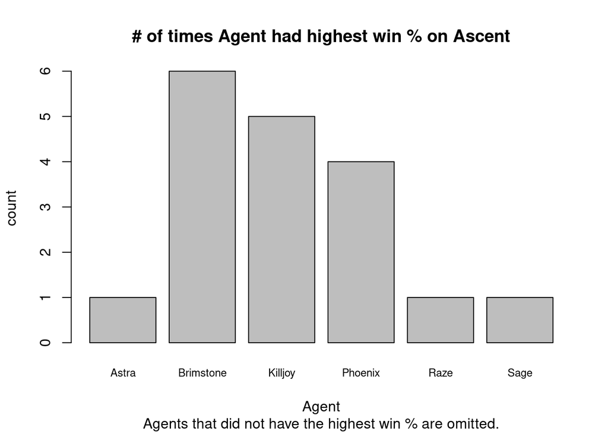

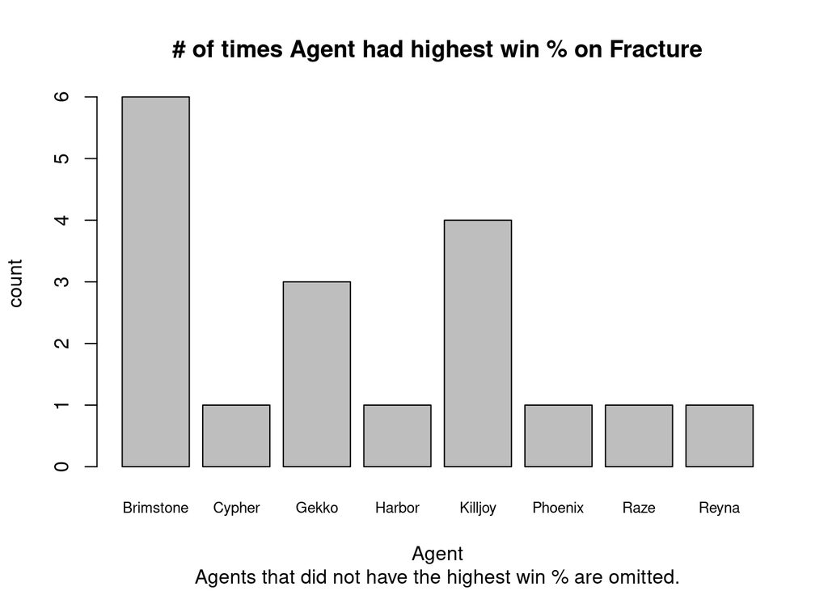

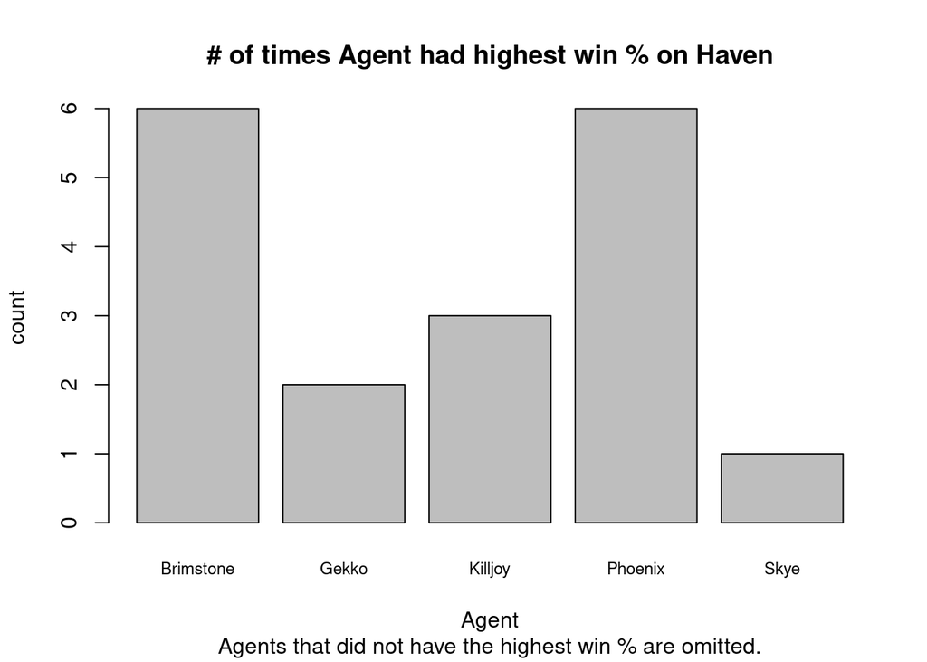

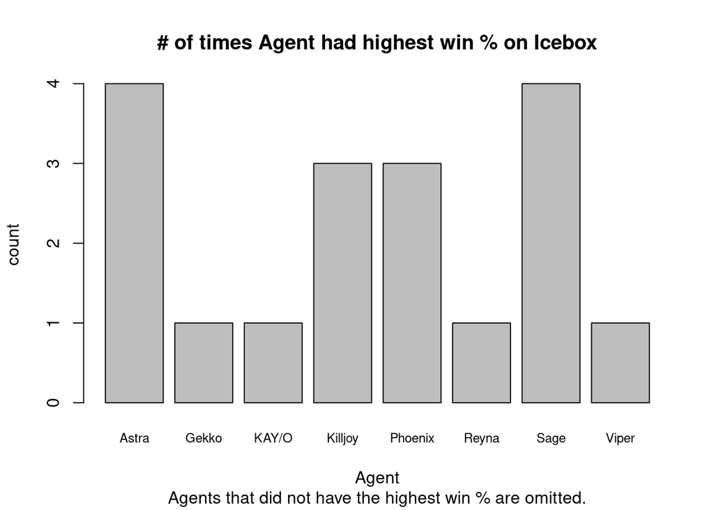

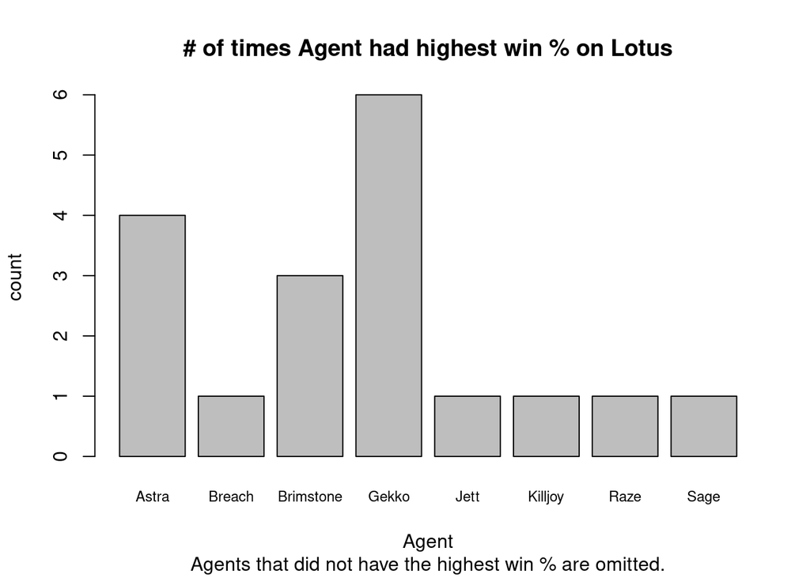

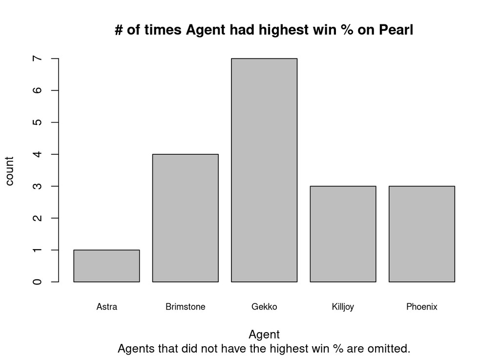

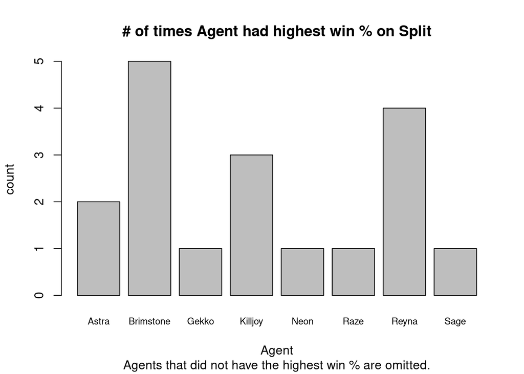

[output not shown]

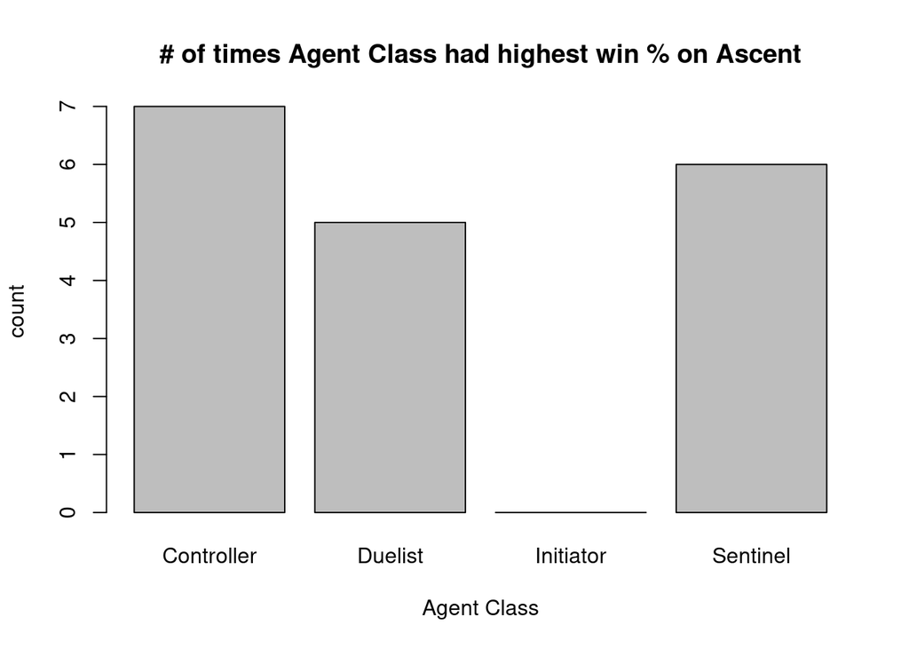

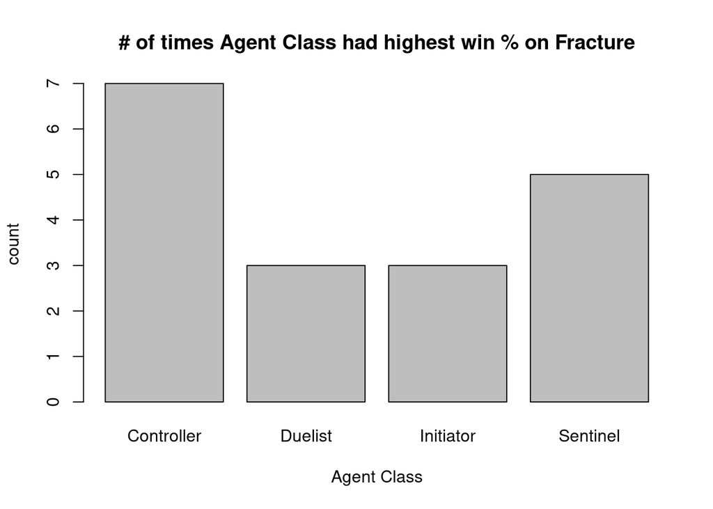

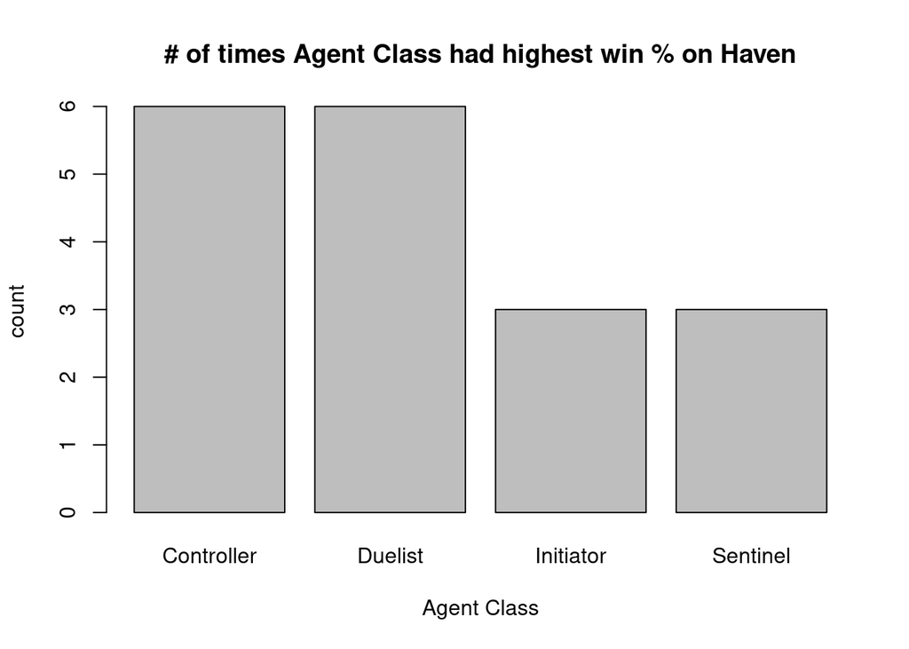

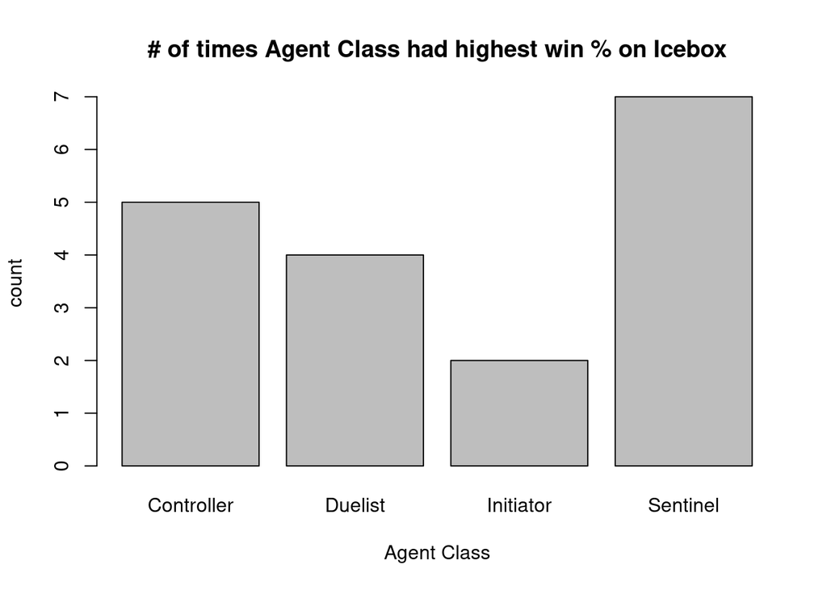

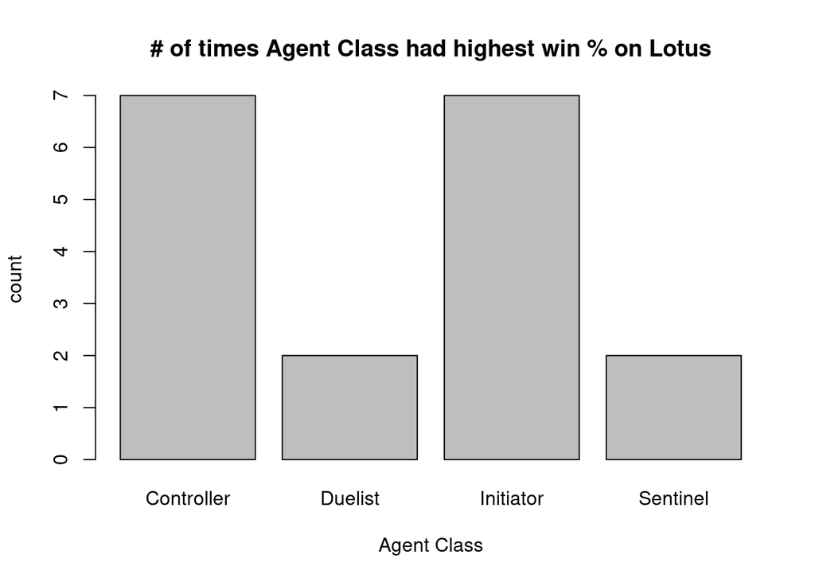

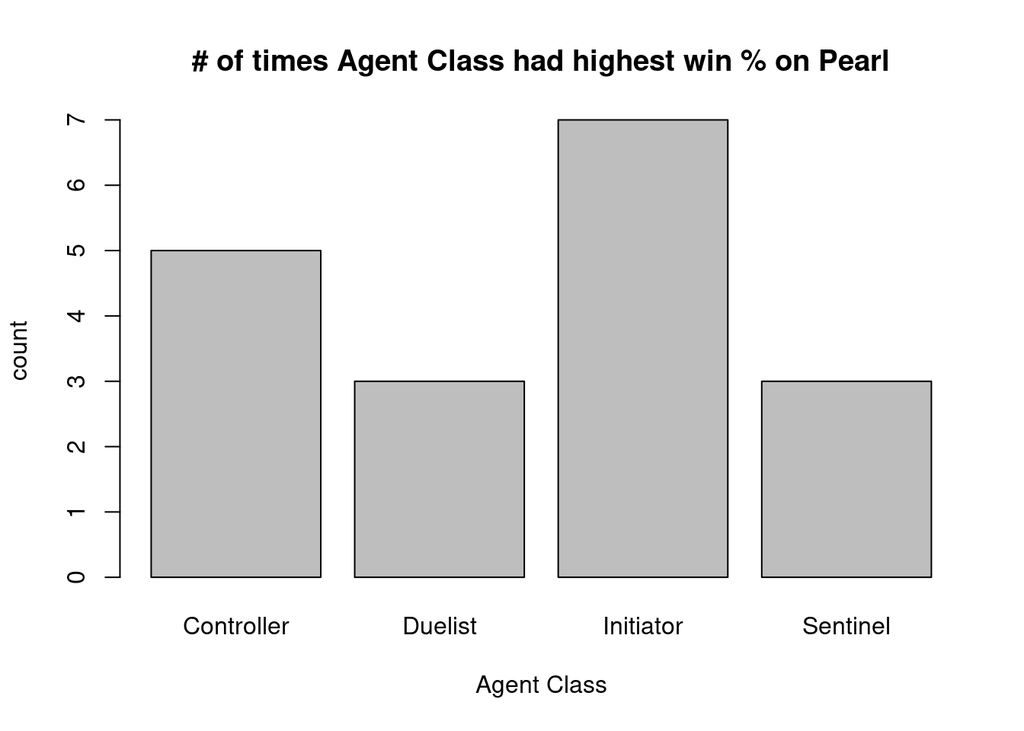

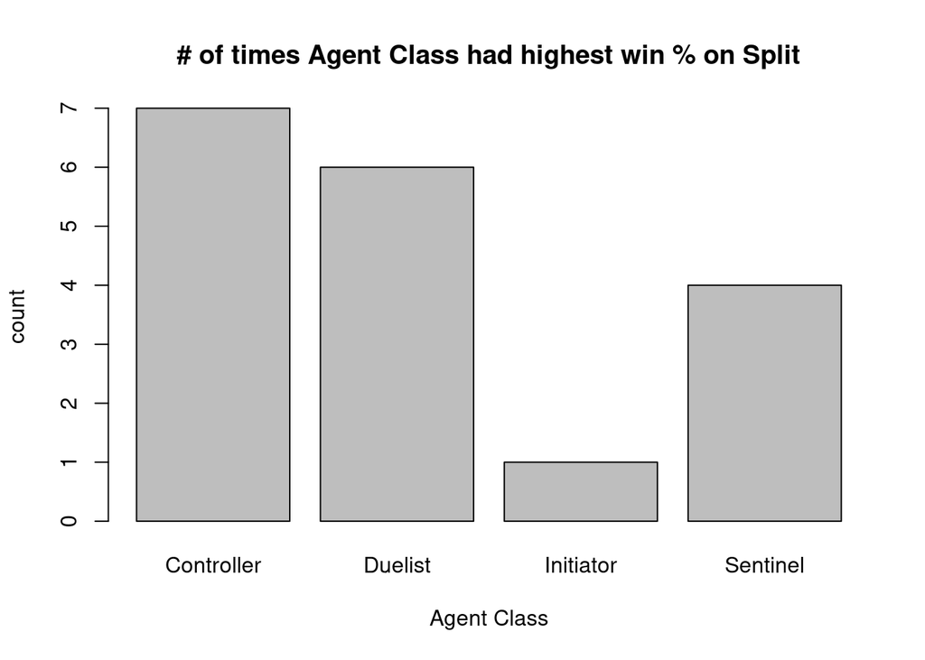

[output not shown]

## Sanity Check

The original data set that I was planning on using, unfortunately for me, did NOT pass the initial sanity check. It was an old data set, meaning it didn’t have some of the newer maps and agents, which wasn’t a big deal since I could still do what I wanted to without those. However, it also had missing data. Some of the `.csv` files were incomplete (either empty or missing several rows) or didn’t import correctly.

Due to this, I decided to create new `.csv` files with current agent data (the Description of Data reflects this data). I also added a new column that isn’t provided by blitz.gg, which is the class of the agent. This was a meticulous process involving copious amounts of fiddling with regex and copying and pasting. Thankfully, it was worth it, as now all of the `.csv` files have the correct amount (21) of rows. I then decided to add a new column, the agent’s class, which required writing a Java function to read and edit the existing `.csv` files.

## Other Details

Thanks to the new data, there are no NAs.

## Next Steps

I haven’t fully figured out how I want to store the data. Currently, each rank for each map is stored as its own `data.frame`, meaning I have

```
## [1] 126
```

individual `data.frame`s. In my mind this is not ideal, and I should at least combine the data from the same maps together into a 3-D thing.

**Most importantly, as it’s directly related to what my project is about, I want to start looking at Rank (level of play) data. I want to find out whether some agents are more effective at lower levels than higher levels or vice-versa. Step 2 looked more at map specific data as it was easiest to get done relatively quickly.**

Currently, most things are nested lists which are hard to traverse and pull data from.

I am also working on creating/optimizing functions to create less global variables and better data structures.